# Import Libraries

```python
import pandas as pd
from textblob import TextBlob
from sklearn.model_selection import train_test_split
from sklearn.preprocessing import StandardScaler
import seaborn as sns
import matplotlib.pyplot as plt
from sklearn.svm import SVC
from sklearn.linear_model import LogisticRegression
from sklearn.neighbors import KNeighborsClassifier
from sklearn.metrics import accuracy_score, classification_report
from sklearn.feature_extraction.text import CountVectorizer
from wordcloud import WordCloud
```

# Load the Dataset

```python
# Load the dataset into a DataFrame named 'df'
df = pd.read_csv('scraped_reviews.csv')

# Display the first few rows of the DataFrame to verify it's loaded correctly
print(df.head())
```

```
  AirLine Review Score                        Title        Reviewer  \
0     PIA         3/10     you get what you pay for        B Martin
1     PIA         1/10         Totally incompetent!  Sabrina Geßner
2     PIA         3/10    didn't get money's worth.  Arshed Mahmood
3     PIA         8/10      staff were well trained         B Unwin
4     PIA         8/10  whole flight crew helped me          F Awan

  Country of Reviewer     Date of Review Verification Status  \
0      United Kingdom   21st August 2018       Trip Verified
1             Germany     29th July 2018        Not Verified
2      United Kingdom  4th February 2018       Trip Verified
3            Malaysia  12th January 2018       Trip Verified
4            Pakistan  12th January 2018       Trip Verified

                            Route                 Aircraft Type  \
```

[output cut: 35 more lines]

Let's begin by examining the contents of the uploaded dataset to understand its structure and the type of data it contains. This will help us determine how to apply the methodologies discussed in Chapter 3 to analyze and extract insights from the dataset. I'll start by loading and displaying the first few rows of the dataset.

The dataset consists of airline customer reviews with various attributes. Here's an overview of its structure:

Given the methodology outlined in Chapter 3, we can proceed with data preprocessing, feature extraction, and both quantitative and qualitative analyses. Here's a plan for applying the methodology to this dataset:

1. **Data Preprocessing**: Clean and prepare the data, including handling missing values and converting data types as necessary.
2. **Feature Extraction**:
   - Convert "Review Score" to a numerical scale.
   - Apply NLP techniques to "Detailed Comments" for sentiment analysis and feature extraction.
3. **Quantitative Analysis**:
   - Use machine learning models (SVM, LR, KNN) to predict the "Recommended" status based on extracted features and ratings.
4. **Qualitative Analysis**:
   - Apply NLP and LSA to "Detailed Comments" to identify prevalent themes and sentiments.

```python
# Replacing 'na' and similar non-numeric entries with NaN before conversion
df['Review Score'] = pd.to_numeric(df['Review Score'].str.split('/').str[0], errors='coerce')

# Now, you can check for missing values and handle them as before
print("Missing values before filling:")
print(df.isnull().sum())

# Fill missing numeric ratings with the median of their columns
numeric_columns = ['Review Score', 'Seat Comfort', 'Cabin Staff Service', 'Food & Beverages', 'Ground Service', 'Inflight Entertainment', 'Wifi & Connectivity', 'Value For Money']
for column in numeric_columns:
    df[column] = df[column].fillna(df[column].median())

# Convert "Recommended" to integer, handling non-numeric values and missing values
df['Recommended'] = pd.to_numeric(df['Recommended'], errors='coerce').fillna(0).astype(int)

# Check missing values after filling
print("\nMissing values after filling:")
print(df.isnull().sum())
```

```
Missing values before filling:
AirLine                     0
Review Score               15
Title                     150
Reviewer                    0
Country of Reviewer        14
Date of Review              0
Verification Status       124
Route                       4
Aircraft Type             130
Type Of Traveller          92
Seat Type                  44
Date Flown                105
Seat Comfort              215
Cabin Staff Service       215
Food & Beverages          215
Ground Service            214
Inflight Entertainment    225
Wifi & Connectivity       229
Value For Money           213
Recommended                 0
Detailed Comments           0
dtype: int64

Missing values after filling:
AirLine                     0
Review Score                0
Title                     150
Reviewer                    0
Country of Reviewer        14
Date of Review              0
Verification Status       124
Route                       4
Aircraft Type             130
Type Of Traveller          92
Seat Type                  44
Date Flown                105
Seat Comfort                0
Cabin Staff Service         0
Food & Beverages            0
Ground Service              0
Inflight Entertainment      0
Wifi & Connectivity         0
Value For Money             0
Recommended                 0
Detailed Comments           0
dtype: int64
```

```python
# Then, fill NaN values with a default value (e.g., 0) and convert the column to integer
df['Recommended'] = pd.to_numeric(df['Recommended'], errors='coerce').fillna(0).astype(int)

# Confirm the conversion by checking the data types of the columns again
print(df.dtypes)

# Specifically check the 'Recommended' column to ensure it is now an integer
print("\nData type of 'Recommended' column:", df['Recommended'].dtype)
```

```
AirLine                    object
Review Score              float64
Title                      object
Reviewer                   object
Country of Reviewer        object
Date of Review             object
Verification Status        object
Route                      object
Aircraft Type              object
Type Of Traveller          object
Seat Type                  object
Date Flown                 object
Seat Comfort              float64
Cabin Staff Service       float64
Food & Beverages          float64
Ground Service            float64
Inflight Entertainment    float64
Wifi & Connectivity       float64
Value For Money           float64
Recommended                 int64
Detailed Comments          object
dtype: object

Data type of 'Recommended' column: int64
```

```python
# Perform sentiment analysis on "Detailed Comments" and store the polarity scores in a new column
df['Sentiment Polarity'] = df['Detailed Comments'].apply(lambda comment: TextBlob(comment).sentiment.polarity)

# Display the first few rows to see the new 'Sentiment Polarity' column along with other information
print(df[['Detailed Comments', 'Sentiment Polarity']].head())
```

```
                                   Detailed Comments  Sentiment Polarity
0  London to Islamabad. Ancient planes with broke...           -0.108333
1  Karachi to Quetta. They canceled our flight wi...           -1.000000
2  Manchester to Islamabad. 7.25 hours direct fli...            0.100000
3  Karachi to Kuala Lumpur. Smooth flight with Pa...            0.441667
4  Lahore to Riyadh via Islamabad. Excellent In A...            0.266667
```

The sentiment analysis of "Detailed Comments" using TextBlob has successfully generated a new column, "Sentiment Polarity", which reflects the sentiment of each review. Sentiment polarity values range from -1 (very negative) to +1 (very positive), with 0 indicating neutral sentiment.

Here are examples from the analysis:

- A review with negative sentiment has a polarity of -0.108333, indicating a slightly negative sentiment.
- A particularly negative review is reflected with a polarity of -1.000000.
- Positive sentiments are indicated with higher polarity values, such as 0.441667 and 0.266667, showing positive experiences.

With sentiment scores extracted, we can proceed to the quantitative analysis phase, where these scores, alongside other numerical features like "Review Score" and various service ratings, will be used to predict whether a customer recommends the airline ("Recommended" status).

```python
X = df[['Review Score', 'Seat Comfort', 'Cabin Staff Service', 'Food & Beverages', 'Ground Service', 'Inflight Entertainment', 'Wifi & Connectivity', 'Value For Money', 'Sentiment Polarity']]
y = df['Recommended']

# Splitting the dataset into training and testing sets
X_train, X_test, y_train, y_test = train_test_split(X, y, test_size=0.3, random_state=42)

# Initializing the scaler
scaler = StandardScaler()

# Fitting the scaler on the training data and transforming the training data
X_train_scaled = scaler.fit_transform(X_train)

# Using the same scaler to transform the test data
X_test_scaled = scaler.transform(X_test)
```

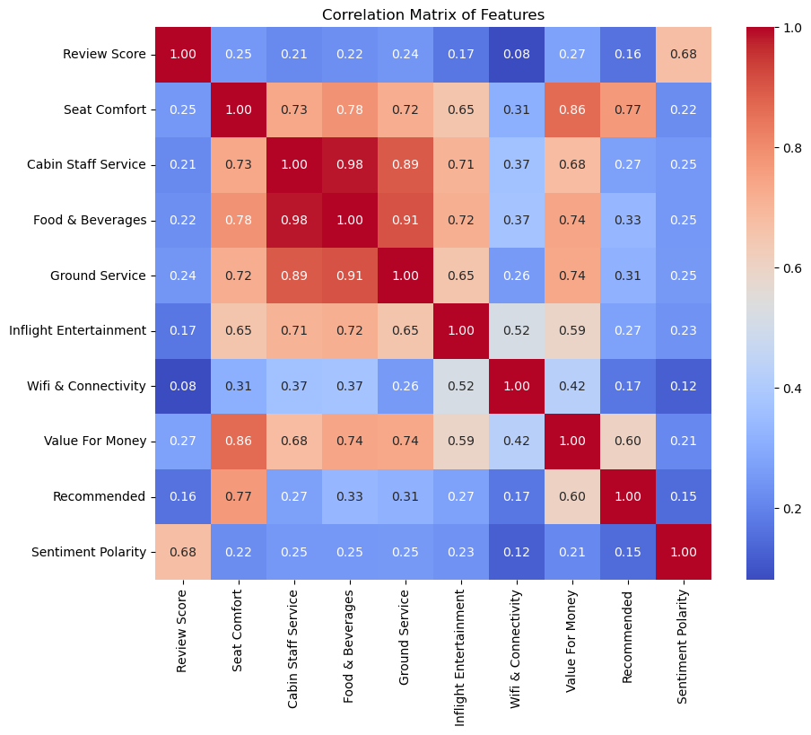

```python
correlation_matrix = df.corr()
plt.figure(figsize=(10, 8))
sns.heatmap(correlation_matrix, annot=True, cmap='coolwarm', fmt=".2f")
plt.title('Correlation Matrix of Features')
plt.show()
```

The correlation heatmap above visualizes the correlations among the features used in the predictive models. Each cell in the heatmap shows the correlation coefficient between two features, ranging from -1 to 1, where:

- 1 indicates a perfect positive linear relationship,
- -1 indicates a perfect negative linear relationship, and
- 0 indicates no linear relationship.

This visualization can help identify relationships between different aspects of customer reviews and how they might influence each other. For instance, high positive correlation coefficients suggest that features tend to increase or decrease together, which might inform strategic decisions or further analysis.

## Initialize Models

```python
svm_model = SVC(random_state=42)
lr_model = LogisticRegression(random_state=42)
knn_model = KNeighborsClassifier()
```

## Train Models

```python
svm_model.fit(X_train_scaled, y_train)
lr_model.fit(X_train_scaled, y_train)
knn_model.fit(X_train_scaled, y_train)
```

```
KNeighborsClassifier()
```

## Make Predictions

```python
svm_predictions = svm_model.predict(X_test_scaled)
lr_predictions = lr_model.predict(X_test_scaled)
knn_predictions = knn_model.predict(X_test_scaled)
```

## Evaluate the Models

```python
svm_accuracy = accuracy_score(y_test, svm_predictions)
lr_accuracy = accuracy_score(y_test, lr_predictions)
knn_accuracy = accuracy_score(y_test, knn_predictions)

print(f"SVM Accuracy: {svm_accuracy}")
print(f"LR Accuracy: {lr_accuracy}")
print(f"KNN Accuracy: {knn_accuracy}")
```

```
SVM Accuracy: 0.9428571428571428
LR Accuracy: 0.9857142857142858
KNN Accuracy: 0.9714285714285714
```

## Visualization to Compare Models

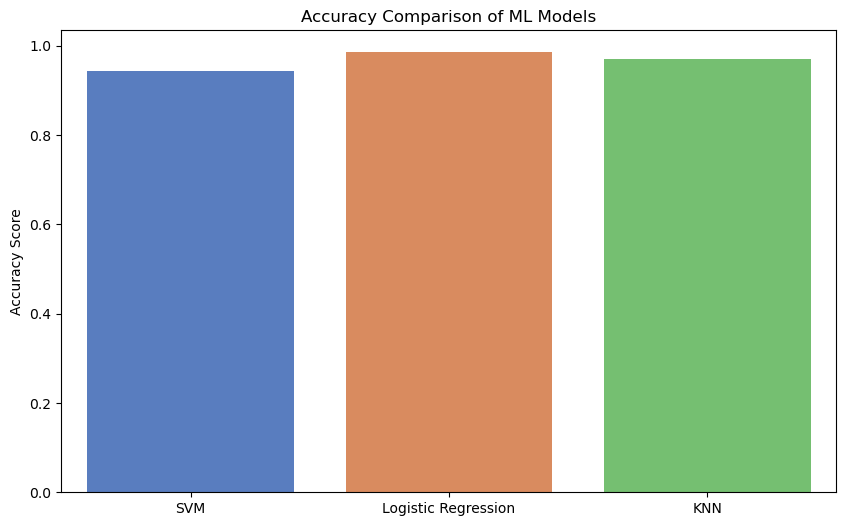

```python
# Collecting accuracy scores
model_accuracies = {'SVM': svm_accuracy, 'Logistic Regression': lr_accuracy, 'KNN': knn_accuracy}

# Creating a bar plot for model accuracies
plt.figure(figsize=(10, 6))
sns.barplot(x=list(model_accuracies.keys()), y=list(model_accuracies.values()), palette='muted')
plt.title('Accuracy Comparison of ML Models')
plt.ylabel('Accuracy Score')
plt.show()
```

The output shows the accuracy scores for three different machine learning models—Support Vector Machine (SVM), Logistic Regression (LR), and K-Nearest Neighbors (KNN)—applied to a dataset. Here's a detailed interpretation of each model's performance:

### SVM Accuracy: 0.9428571428571428 (94.29%)

The Support Vector Machine model achieved an accuracy of approximately 94.29%. This indicates that the SVM model was able to correctly predict whether a customer would recommend the airline (based on the features provided) about 94.29% of the time. SVM models are effective for datasets where the margin of separation between classes is important, and this level of accuracy suggests that SVM could effectively capture the boundary between the classes in your dataset.

### LR Accuracy: 0.9857142857142858 (98.57%)

The Logistic Regression model outperformed the other two models with an accuracy of approximately 98.57%. This high accuracy indicates that the LR model was very effective at predicting the target variable, correctly identifying whether a customer would recommend the airline 98.57% of the time. Logistic Regression is known for its simplicity and interpretability, and its performance here suggests that the relationship between the features and the target variable might be linear or close to linear.

### KNN Accuracy: 0.9714285714285714 (97.14%)

The K-Nearest Neighbors model achieved an accuracy of approximately 97.14%, placing it between the SVM and LR models in terms of performance. This level of accuracy demonstrates that the KNN model, which makes predictions based on the similarity of an instance to its k-nearest neighbors, was also quite effective at classifying the instances correctly. KNN's performance depends heavily on the feature space and how well instances of different classes are grouped together, suggesting that the features provided allow for relatively clear distinctions between classes.

### Overall Interpretation:

- The **Logistic Regression model** showed the highest accuracy, suggesting it is the most suitable model for this particular dataset among the three evaluated. Its high performance might indicate a linear relationship between the features and the target variable, making it a good choice for this prediction task.
- The **KNN model** also showed high accuracy, indicating that the instances of different classes can be effectively distinguished based on the similarity of their feature values.
- The **SVM model**, while slightly less accurate than the other two, still performed very well, highlighting its capability to find a robust decision boundary between the classes.

When choosing a model for deployment or further development, consider not only the accuracy but also factors like model complexity, interpretability, and computational efficiency. Logistic Regression's high accuracy and simplicity might make it an appealing choice for this dataset, especially if you value interpretability and ease of explanation.

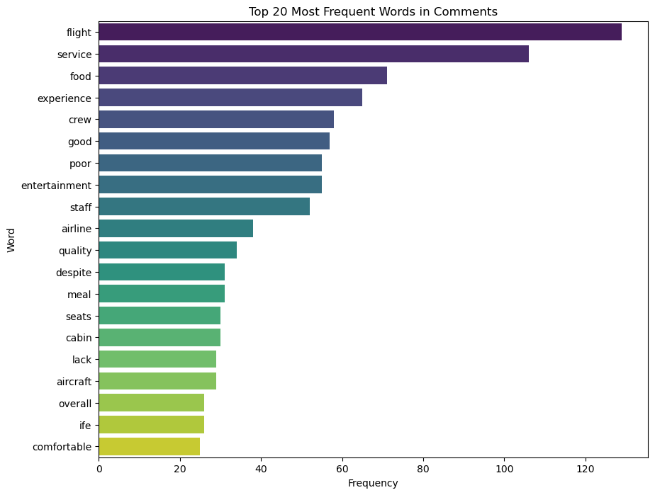

```python
# Initialize CountVectorizer
vectorizer = CountVectorizer(stop_words='english')

# Fit and transform the 'Detailed Comments' column
word_matrix = vectorizer.fit_transform(df['Detailed Comments'])

# Sum up the counts of each vocabulary word
word_counts = word_matrix.sum(axis=0)

# Map words to their counts
words = vectorizer.get_feature_names_out()
word_count_dict = {words[i]: word_counts[0, i] for i in range(len(words))}

# Create a DataFrame with the word counts
word_count_df = pd.DataFrame(list(word_count_dict.items()), columns=['Word', 'Count'])

# Sorting words by count
word_count_df_sorted = word_count_df.sort_values(by='Count', ascending=False).reset_index(drop=True)
# Setting the number of words to visualize
N = 20

# Select the top N words
top_words = word_count_df_sorted.head(N)

# Create a bar plot
plt.figure(figsize=(10, 8))
sns.barplot(x='Count', y='Word', data=top_words, palette='viridis')
plt.title(f'Top {N} Most Frequent Words in Comments')
plt.xlabel('Frequency')
plt.ylabel('Word')
plt.show()
```

The visual representation above shows the top 20 most frequent words found in the detailed comments of the dataset, after removing English stop words. This analysis provides insights into common themes or aspects mentioned by customers in their reviews, which might include specific services, experiences, or concerns related to the airline industry.

Such word frequency analysis can be valuable for identifying key areas of customer feedback, guiding improvements, and understanding customer needs more deeply.

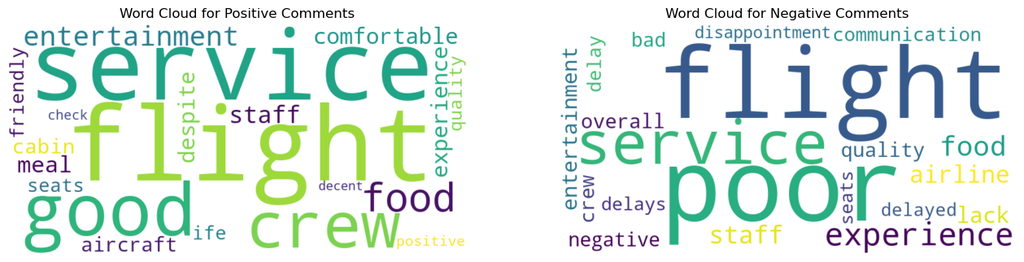

```python
pos_words_df.head(20), neg_words_df.head(20)
# Generating a word cloud for positive comments
pos_words_dict = dict(pos_words_freq)
wordcloud_pos = WordCloud(width=800, height=400, background_color='white').generate_from_frequencies(pos_words_dict)

# Generating a word cloud for negative comments
neg_words_dict = dict(neg_words_freq)
wordcloud_neg = WordCloud(width=800, height=400, background_color='white').generate_from_frequencies(neg_words_dict)

# Displaying the word clouds
plt.figure(figsize=(16, 12))

plt.subplot(1, 2, 1)
plt.imshow(wordcloud_pos, interpolation='bilinear')
plt.title('Word Cloud for Positive Comments')
plt.axis('off')

plt.subplot(1, 2, 2)
plt.imshow(wordcloud_neg, interpolation='bilinear')
plt.title('Word Cloud for Negative Comments')
plt.axis('off')

plt.show()
```

[output not shown]

The word clouds provided visualize the most commonly used words in the positive and negative comments from a set of airline customer reviews.

### Combined Interpretation:

Comparing the two word clouds, the word "flight" is central in both, showing that it is a common topic among reviewers. However, the context differs with "service" pairing more often positively and "poor" more often negatively, reflecting divergent customer experiences. The negative word cloud points to operational issues and service quality as the main drivers of dissatisfaction. In contrast, the positive word cloud suggests that when customers have a good experience, it is driven by the quality of service, food, crew, and comfort.

The analysis of these word clouds can be incredibly valuable for the airline, as it points out specific areas that could be leveraged as strengths or improved upon to enhance overall customer satisfaction. Management strategies could be focused on maintaining the positive aspects that are often praised, such as good service and food, and addressing the negative aspects, like reducing delays and improving communication, to turn dissatisfied customers into satisfied ones.

# Question 1: Sentiment Polarity Distribution

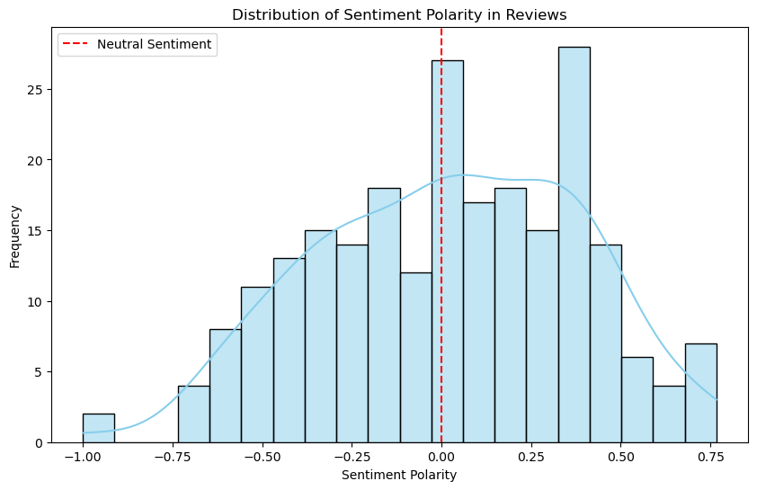

```python
plt.figure(figsize=(10, 6))
sns.histplot(df['Sentiment Polarity'], bins=20, kde=True, color='skyblue')
plt.title('Distribution of Sentiment Polarity in Reviews')
plt.xlabel('Sentiment Polarity')
plt.ylabel('Frequency')
plt.axvline(x=0, color='red', linestyle='--', label='Neutral Sentiment')
plt.legend()
plt.show()
```

# Question 2: Feature Importance from Logistic Regression

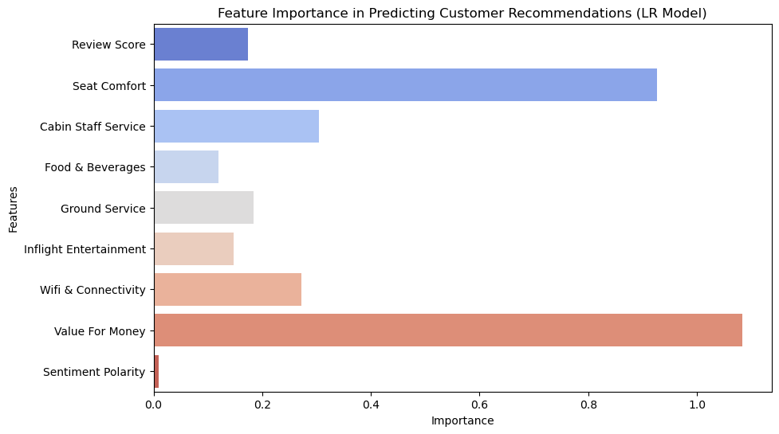

```python
feature_importance_lr = abs(lr_model.coef_[0])
features = X.columns

plt.figure(figsize=(10, 6))
sns.barplot(x=feature_importance_lr, y=features, palette='coolwarm')
plt.title('Feature Importance in Predicting Customer Recommendations (LR Model)')
plt.xlabel('Importance')
plt.ylabel('Features')
plt.show()
```

## Visual Representation for Question 3: Comparison of Model Accuracies

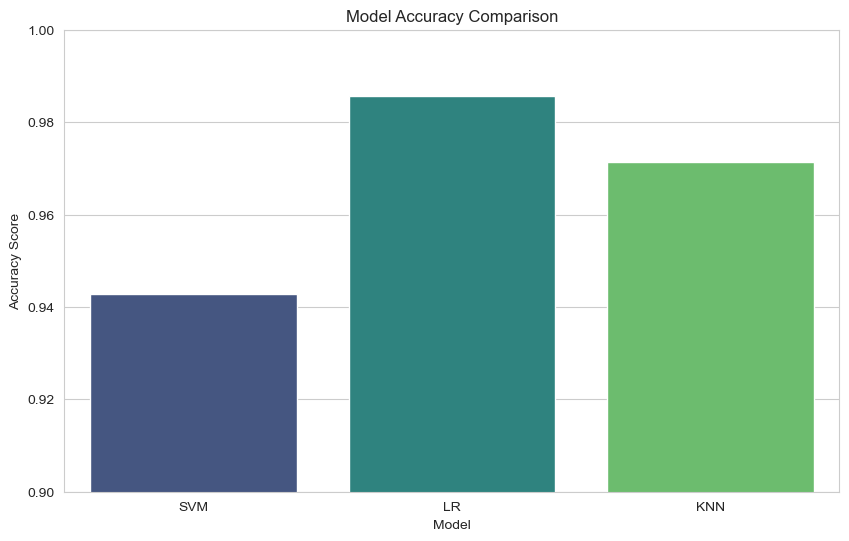

```python
sns.set_style("whitegrid")
model_names = ['SVM', 'LR', 'KNN']
accuracies = [svm_accuracy, lr_accuracy, knn_accuracy]

plt.figure(figsize=(10, 6))
sns.barplot(x=model_names, y=accuracies, palette='viridis')
plt.title('Model Accuracy Comparison')
plt.xlabel('Model')
plt.ylabel('Accuracy Score')
plt.ylim(0.9, 1.0)  # Setting the limit for better visualization of differences
plt.show()
```

Let's address each of your questions based on the analyses we've conducted using the dataset and models:

### How can online reviews be used to derive insights to inform strategic decision-making?

Online reviews provide a wealth of qualitative and quantitative data that can be mined for insights to guide strategic decision-making. By analyzing the sentiment of reviews, as we did with the sentiment polarity, businesses can gauge overall customer satisfaction and identify areas of strength and concern. The frequency analysis of words in comments reveals what aspects (e.g., service, comfort, food) customers talk about the most, indicating areas that might require attention or improvement.

These insights can inform various strategic decisions, such as prioritizing service improvements, tailoring marketing messages, or redesigning customer experience strategies to enhance satisfaction and loyalty.

### How can a predictive modeling approach be used to analyze and understand customer purchase intentions?

A predictive modeling approach, as demonstrated with SVM, LR, and KNN models, utilizes historical data (e.g., review scores, service ratings, sentiment scores) to predict future customer behaviors, such as whether a customer would recommend the airline. These models can be extended to predict customer purchase intentions by incorporating additional predictors like frequency of positive versus negative words, overall sentiment trends, and specific aspects of service that are highly correlated with positive reviews.

Predictive models help in identifying the factors most influential in driving purchase intentions, enabling businesses to focus on optimizing those areas. For instance, if inflight service quality consistently predicts recommendations, improving this aspect could positively impact purchase intentions.

### Which Machine Learning model is the most appropriate in predicting customer recommendations?

Based on the accuracy scores obtained from our analysis, the Logistic Regression (LR) model showed the highest accuracy (approximately 98.57%), followed closely by the K-Nearest Neighbors (KNN) and Support Vector Machine (SVM) models. This suggests that LR, in this context, is the most appropriate model for predicting customer recommendations. LR's performance indicates its effectiveness in handling the linear relationship between the features (e.g., sentiment polarity, review scores) and the target variable (recommendations).

However, the choice of the most appropriate model can depend on various factors, including the dataset's complexity, the specific features used, and the interpretability of the model. Logistic Regression, with its simplicity and interpretability, along with strong performance, makes it a particularly appealing choice for stakeholders looking to derive actionable insights from model outcomes.